# Survival Analysis 期中考试复习

P8108 Midterm Review

2025-10-23

# Chapter 1: Basic Concepts

## 1.1 基本定义与记号

### 生存时间和基本函数

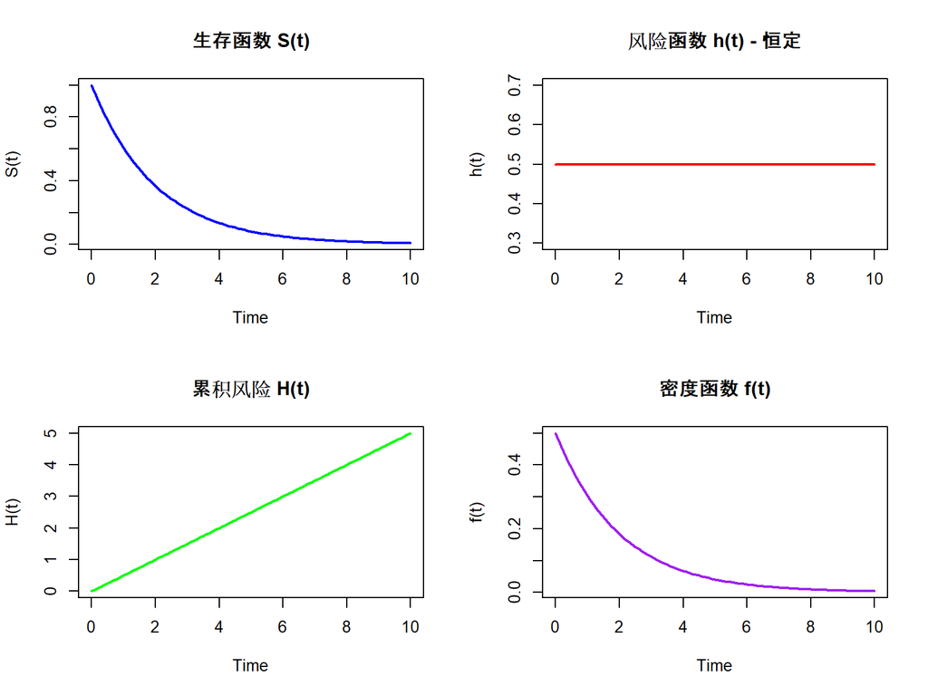

```r
# 示例：生成模拟数据展示基本函数关系
t <- seq(0, 10, 0.1)
lambda <- 0.5  # 指数分布参数

# 四个基本函数
h_t <- lambda  # 恒定hazard
H_t <- lambda * t  # 累积hazard
S_t <- exp(-lambda * t)  # 生存函数
f_t <- lambda * exp(-lambda * t)  # 密度函数
F_t <- 1 - S_t  # 累积分布函数

# 可视化
par(mfrow = c(2, 2))
plot(t, S_t, type = "l", lwd = 2, col = "blue",
     main = "生存函数 S(t)", ylab = "S(t)", xlab = "Time")
plot(t, h_t * rep(1, length(t)), type = "l", lwd = 2, col = "red",
     main = "风险函数 h(t) - 恒定", ylab = "h(t)", xlab = "Time")
plot(t, H_t, type = "l", lwd = 2, col = "green",
     main = "累积风险 H(t)", ylab = "H(t)", xlab = "Time")
plot(t, f_t, type = "l", lwd = 2, col = "purple",
     main = "密度函数 f(t)", ylab = "f(t)", xlab = "Time")
```

```r
par(mfrow = c(1, 1))
```

**关键关系式：**

- $h(t) = \frac{f(t)}{S(t)} = -\frac{d\log S(t)}{dt}$
- $S(t) = \exp(-H(t)) = \exp\left(-\int_0^t h(u)du\right)$
- $H(t) = -\log S(t)$
- $f(t) = h(t)S(t)$

### 条件概率计算

```r
# 示例：指数分布的条件概率
# 已知存活到时间s，再存活到s+t的概率

lambda <- 0.3
s <- 2
t <- 3

# P(T > s+t | T > s) = S(s+t) / S(s)
S_s <- exp(-lambda * s)
S_st <- exp(-lambda * (s + t))
cond_prob <- S_st / S_s

cat("P(T >", s+t, "| T >", s, ") =", cond_prob, "\n")
```

```
## P(T > 5 | T > 2 ) = 0.4065697
```

```r
cat("直接计算 exp(-lambda*t) =", exp(-lambda * t), "\n")
```

```
## 直接计算 exp(-lambda*t) = 0.4065697
```

```r
cat("验证无记忆性质（指数分布）\n")
```

```
## 验证无记忆性质（指数分布）
```

## 1.2 删失类型

### 右删失示例

```r
# 模拟右删失数据
set.seed(123)
n <- 100

# 真实事件时间（指数分布）
true_time <- rexp(n, rate = 0.2)

# 删失时间（均匀分布）
censor_time <- runif(n, 0, 15)

# 观测时间和删失指示
obs_time <- pmin(true_time, censor_time)
event <- as.numeric(true_time <= censor_time)

cat("样本量:", n, "\n")
```

```
## 样本量: 100
```

```r
cat("事件数:", sum(event), "\n")
```

```
## 事件数: 73
```

```r
cat("删失数:", sum(1 - event), "\n")
```

```
## 删失数: 27
```

```r
cat("删失率:", round(mean(1 - event) * 100, 1), "%\n")
```

```
## 删失率: 27 %
```

```r
# 创建生存对象
surv_obj <- Surv(time = obs_time, event = event)
head(data.frame(obs_time, event, surv_obj), 10)
```

```
##      obs_time event    surv_obj
## 1   4.2172863     1   4.2172863
## 2   2.8830514     1   2.8830514
## 3   6.6452743     1   6.6452743
## 4   0.1578868     1   0.1578868
## 5   0.2810549     1   0.2810549
## 6   1.5825061     1   1.5825061
## 7   1.5711365     1   1.5711365
## 8   0.7263340     1   0.7263340
## 9  12.5965165     0 12.5965165+
## 10  0.1457672     1   0.1457672
```

### 左截断（延迟进入）示例

```r
# 示例：研究从1990年开始，但只观察1985年后出生且存活到1990年的个体
set.seed(456)
n <- 50

# 出生时间（1985-1990之间）
birth_year <- runif(n, 1985, 1990)

# 进入研究时间（1990年）
entry_year <- 1990

# 事件时间（从出生算起）
event_year <- birth_year + rexp(n, rate = 0.1)

# 删失时间（研究结束于2000年）
censor_year <- 2000

# 只观察存活到1990年的个体
entry_time <- entry_year - birth_year  # 左截断时间
obs_time <- pmin(event_year, censor_year) - birth_year
event <- as.numeric(event_year < censor_year)

# 左截断数据
left_trunc_data <- data.frame(
  entry = entry_time,
  exit = obs_time,
  event = event
)

head(left_trunc_data)
```

```
##       entry      exit event
## 1 4.5522420  2.230091     1
## 2 3.9474384  9.505201     1
## 3 1.3352237  0.956499     1
## 4 0.7393323  7.097098     1
## 5 1.0580105  8.870436     1
## 6 3.3402002 13.274667     1
```

```r
cat("\n左截断：所有个体在时间", unique(entry_time), "进入研究\n")
```

[output not shown]

# Chapter 2: Kaplan-Meier 估计

## 2.1 KM估计量的计算

### 手工计算示例

```r
# 示例数据：2, 3+, 5, 8, 8+  (+ 表示删失)
time <- c(2, 3, 5, 8, 8)
event <- c(1, 0, 1, 1, 0)

# 创建KM表格
km_table <- data.frame(
  t = c(0, 2, 3, 5, 8),
  n_risk = c(5, 5, 4, 3, 2),
  n_event = c(0, 1, 0, 1, 1),
  n_censor = c(0, 0, 1, 0, 1),
  survival = c(1, 0.8, 0.8, 0.533, 0.267)
)

km_table$hazard <- km_table$n_event / km_table$n_risk
km_table$se_component <- ifelse(km_table$n_event > 0,
                                 km_table$n_event / (km_table$n_risk * (km_table$n_risk - km_table$n_event)),
                                 0)

print(km_table)
```

```
##   t n_risk n_event n_censor survival    hazard se_component
## 1 0      5       0        0    1.000 0.0000000    0.0000000
## 2 2      5       1        0    0.800 0.2000000    0.0500000
## 3 3      4       0        1    0.800 0.0000000    0.0000000
## 4 5      3       1        0    0.533 0.3333333    0.1666667
## 5 8      2       1        1    0.267 0.5000000    0.5000000
```

```r
# 计算Greenwood标准误（在t=8时）
greenwood_sum <- sum(km_table$se_component[km_table$t <= 8 & km_table$n_event > 0])
se_s8 <- km_table$survival[km_table$t == 8] * sqrt(greenwood_sum)

cat("\nGreenwood方差成分之和:", greenwood_sum, "\n")
```

```
##
## Greenwood方差成分之和: 0.7166667
```

```r
cat("SE(S(8)):", se_s8, "\n")
```

```
## SE(S(8)): 0.226032
```

### 使用R的survival包

```r
# 使用survival包计算
km_fit <- survfit(Surv(time, event) ~ 1)

# 查看详细结果
summary(km_fit)
```

```
## Call: survfit(formula = Surv(time, event) ~ 1)
##
##  time n.risk n.event survival std.err lower 95% CI upper 95% CI
##     2      5       1    0.800   0.179       0.5161            1
##     5      3       1    0.533   0.248       0.2142            1
##     8      2       1    0.267   0.226       0.0507            1
```

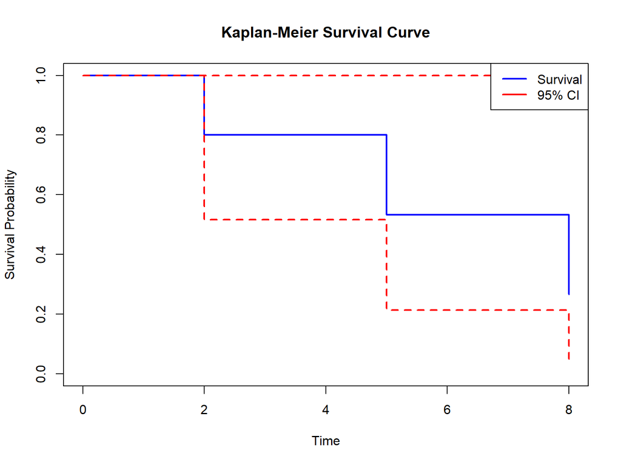

```r
# 绘制KM曲线
plot(km_fit, conf.int = TRUE,
     xlab = "Time", ylab = "Survival Probability",
     main = "Kaplan-Meier Survival Curve",
     col = c("blue", "red", "red"),
     lwd = 2)
legend("topright", c("Survival", "95% CI"),
       col = c("blue", "red"), lwd = 2)
```

## 2.2 置信区间

### 三种置信区间方法

```r
# 使用lung数据集
data(lung)
lung_clean <- lung %>% filter(!is.na(sex))

# 计算不同类型的置信区间
km_plain <- survfit(Surv(time, status - 1) ~ 1, data = lung_clean, conf.type = "plain")
km_log <- survfit(Surv(time, status - 1) ~ 1, data = lung_clean, conf.type = "log")
km_loglog <- survfit(Surv(time, status - 1) ~ 1, data = lung_clean, conf.type = "log-log")

# 比较在特定时间点的CI
time_point <- 365

# 提取在该时间点的估计
summary(km_plain, times = time_point)$surv
```

```
## [1] 0.4092416
```

```r
summary(km_log, times = time_point)$surv
```

```
## [1] 0.4092416
```

```r
summary(km_loglog, times = time_point)$surv
```

```
## [1] 0.4092416
```

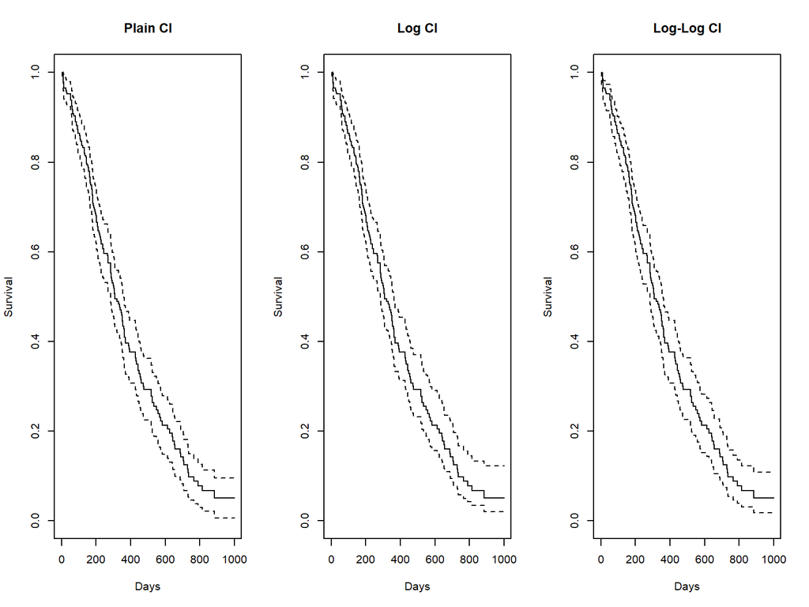

```r
# 可视化比较
par(mfrow = c(1, 3))
plot(km_plain, conf.int = TRUE, main = "Plain CI",
     xlab = "Days", ylab = "Survival", xlim = c(0, 1000))
plot(km_log, conf.int = TRUE, main = "Log CI",
     xlab = "Days", ylab = "Survival", xlim = c(0, 1000))
plot(km_loglog, conf.int = TRUE, main = "Log-Log CI", # Default method
     xlab = "Days", ylab = "Survival", xlim = c(0, 1000))
```

```r
par(mfrow = c(1, 1))
```

## 2.3 Backward Calculation（反推计算）

### 从S(t)反推d_i和r_i

```r
# 示例：给定S(t)和样本量，反推事件数和风险集大小
n <- 21
survival_estimates <- c(1.000, 0.905, 0.762, 0.667, 0.571)
time_points <- c(0, 2, 5, 7, 10)

# 创建表格
backward_table <- data.frame(
  time = time_points,
  S_t = survival_estimates,
  S_prev = c(NA, survival_estimates[-length(survival_estimates)])
)

# 计算d_i/r_i
backward_table$d_over_r <- with(backward_table,
                                 ifelse(!is.na(S_prev), 1 - S_t/S_prev, NA))

# 假设从r_1 = n开始
backward_table$r_i <- c(21, 21, 18, 16, 14)
backward_table$d_i <- round(backward_table$d_over_r * backward_table$r_i)
backward_table$c_i <- c(0, 0, 2, 1, NA)  # 删失数

print(backward_table)
```

```
##   time   S_t S_prev  d_over_r r_i d_i c_i
## 1    0 1.000     NA        NA  21  NA   0
## 2    2 0.905  1.000 0.0950000  21   2   0
## 3    5 0.762  0.905 0.1580110  18   3   2
## 4    7 0.667  0.762 0.1246719  16   2   1
## 5   10 0.571  0.667 0.1439280  14   2  NA
```

```r
# 验证
cat("\n验证:\n")
```

```
##
## 验证:
```

```r
cat("总事件数:", sum(backward_table$d_i, na.rm = TRUE), "\n")
```

```
## 总事件数: 9
```

```r
cat("总删失数:", sum(backward_table$c_i, na.rm = TRUE), "\n")
```

```
## 总删失数: 3
```

```r
cat("总计:", sum(backward_table$d_i, na.rm = TRUE) + sum(backward_table$c_i, na.rm = TRUE), "\n")
```

```
## 总计: 12
```

## 2.4 生存百分位数和RMST

```r
# 使用lung数据
km_lung <- survfit(Surv(time, status - 1) ~ 1, data = lung_clean)

# 提取中位生存时间
median_surv <- surv_median(km_lung)
print(median_surv)
```

```
##   strata median lower upper
## 1    All    310   285   363
```

```r
# 计算25%, 50%, 75%分位数
quantile(km_lung, probs = c(0.25, 0.5, 0.75))
```

```
## $quantile
##  25  50  75
## 170 310 550
##
## $lower
##  25  50  75
## 145 285 460
##
## $upper
##  25  50  75
## 197 363 654
```

```r
# 计算RMST (Restricted Mean Survival Time)
# 限制在tau = 365天
tau <- 365
rmst_result <- summary(km_lung, rmean = tau)
print(rmst_result)
```

```
## Call: survfit(formula = Surv(time, status - 1) ~ 1, data = lung_clean)
##
##  time n.risk n.event survival std.err lower 95% CI upper 95% CI
##     5    228       1   0.9956 0.00438       0.9871        1.000
##    11    227       3   0.9825 0.00869       0.9656        1.000
##    12    224       1   0.9781 0.00970       0.9592        0.997
##    13    223       2   0.9693 0.01142       0.9472        0.992
##    15    221       1   0.9649 0.01219       0.9413        0.989
##    26    220       1   0.9605 0.01290       0.9356        0.986
##    30    219       1   0.9561 0.01356       0.9299        0.983
##    31    218       1   0.9518 0.01419       0.9243        0.980
##    53    217       2   0.9430 0.01536       0.9134        0.974
##    54    215       1   0.9386 0.01590       0.9079        0.970
##    59    214       1   0.9342 0.01642       0.9026        0.967
##    60    213       2   0.9254 0.01740       0.8920        0.960
```

[output cut: 127 more lines]

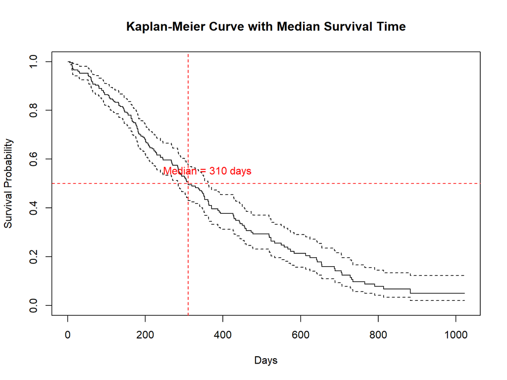

```r
# 可视化：显示中位生存时间
plot(km_lung, conf.int = TRUE,
     xlab = "Days", ylab = "Survival Probability",
     main = "Kaplan-Meier Curve with Median Survival Time")
abline(h = 0.5, col = "red", lty = 2)
abline(v = median_surv$median, col = "red", lty = 2)
text(median_surv$median + 50, 0.55,
     paste("Median =", round(median_surv$median, 1), "days"), col = "red")
```

## 2.5 其他估计量

### Nelson-Aalen估计量

```r
# 计算Nelson-Aalen累积风险估计
km_lung <- survfit(Surv(time, status - 1) ~ 1, data = lung_clean)

# 提取累积风险
na_est <- data.frame(
  time = km_lung$time,
  n_event = km_lung$n.event,
  n_risk = km_lung$n.risk,
  cumhaz = cumsum(km_lung$n.event / km_lung$n.risk)  # Nelson-Aalen
)

# KM隐含的累积风险
na_est$cumhaz_km <- -log(km_lung$surv)

# Fleming-Harrington估计
na_est$surv_fh <- exp(-na_est$cumhaz)
na_est$surv_km <- km_lung$surv

# 比较
head(na_est, 10)
```

```
##    time n_event n_risk      cumhaz   cumhaz_km   surv_fh   surv_km
## 1     5       1    228 0.004385965 0.004395611 0.9956236 0.9956140
## 2    11       3    227 0.017601824 0.017699577 0.9825522 0.9824561
## 3    12       1    224 0.022066110 0.022173857 0.9781756 0.9780702
## 4    13       2    223 0.031034720 0.031182927 0.9694419 0.9692982
## 5    15       1    221 0.035559606 0.035718083 0.9650652 0.9649123
## 6    26       1    220 0.040105061 0.040273899 0.9606885 0.9605263
## 7    30       1    219 0.044671271 0.044850566 0.9563118 0.9561404
## 8    31       1    218 0.049258427 0.049448275 0.9519351 0.9517544
## 9    53       2    217 0.058475017 0.058707601 0.9432018 0.9429825
## 10   54       1    215 0.063126180 0.063369614 0.9388250 0.9385965
```

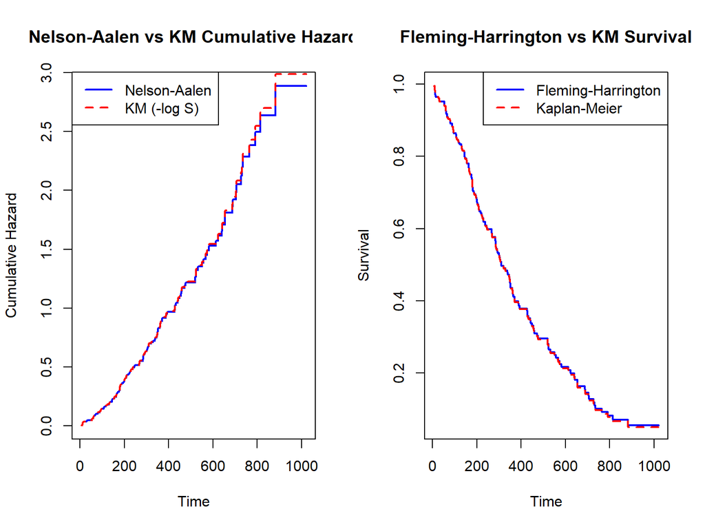

```r
# 可视化比较
par(mfrow = c(1, 2))
plot(na_est$time, na_est$cumhaz, type = "s", col = "blue", lwd = 2,
     xlab = "Time", ylab = "Cumulative Hazard",
     main = "Nelson-Aalen vs KM Cumulative Hazard")
lines(na_est$time, na_est$cumhaz_km, type = "s", col = "red", lwd = 2, lty = 2)
legend("topleft", c("Nelson-Aalen", "KM (-log S)"),
       col = c("blue", "red"), lwd = 2, lty = c(1, 2))

plot(na_est$time, na_est$surv_fh, type = "s", col = "blue", lwd = 2,
     xlab = "Time", ylab = "Survival",
     main = "Fleming-Harrington vs KM Survival")
lines(na_est$time, na_est$surv_km, type = "s", col = "red", lwd = 2, lty = 2)
legend("topright", c("Fleming-Harrington", "Kaplan-Meier"),
       col = c("blue", "red"), lwd = 2, lty = c(1, 2))
```

```r
par(mfrow = c(1, 1))
```

# Chapter 3: 比较两组生存曲线

## 3.1 Logrank检验

### 手工计算示例

```r
# 示例数据：两组的生存时间
group1_time <- c(6, 7, 10, 15, 19, 25)
group1_event <- c(1, 1, 1, 1, 0, 0)

group2_time <- c(1, 1, 2, 2, 3, 4, 4, 8, 17, 23)
group2_event <- c(1, 1, 1, 1, 1, 0, 1, 1, 0, 0)

# 合并数据
surv_data <- data.frame(
  time = c(group1_time, group2_time),
  event = c(group1_event, group2_event),
  group = c(rep("Group 1", length(group1_time)),
            rep("Group 2", length(group2_time)))
)

# 使用survival包进行logrank检验
logrank_test <- survdiff(Surv(time, event) ~ group, data = surv_data)
print(logrank_test)
```

```
## Call:
## survdiff(formula = Surv(time, event) ~ group, data = surv_data)
##
##                N Observed Expected (O-E)^2/E (O-E)^2/V
## group=Group 1  6        4     5.78     0.549      1.25
## group=Group 2 10        7     5.22     0.609      1.25
##
##  Chisq= 1.2  on 1 degrees of freedom, p= 0.3
```

```r
# 手工构建logrank表格（仅显示有事件的时间）
event_times <- sort(unique(surv_data$time[surv_data$event == 1]))

logrank_table <- data.frame(
  time = event_times,
  n1 = sapply(event_times, function(t) sum(surv_data$time >= t & surv_data$group == "Group 1")),
  n2 = sapply(event_times, function(t) sum(surv_data$time >= t & surv_data$group == "Group 2")),
  d1 = sapply(event_times, function(t) sum(surv_data$time == t & surv_data$event == 1 & surv_data$group == "Group 1")),
  d2 = sapply(event_times, function(t) sum(surv_data$time == t & surv_data$event == 1 & surv_data$group == "Group 2"))
)

logrank_table$n_total <- logrank_table$n1 + logrank_table$n2
logrank_table$d_total <- logrank_table$d1 + logrank_table$d2
logrank_table$E1 <- (logrank_table$n1 * logrank_table$d_total) / logrank_table$n_total
logrank_table$V <- with(logrank_table,
                        (n1 * n2 * d_total * (n_total - d_total)) /
                          (n_total^2 * (n_total - 1)))

print(logrank_table)
```

```
##   time n1 n2 d1 d2 n_total d_total        E1         V
## 1    1  6 10  0  2      16       2 0.7500000 0.4375000
## 2    2  6  8  0  2      14       2 0.8571429 0.4521193
## 3    3  6  6  0  1      12       1 0.5000000 0.2500000
## 4    4  6  5  0  1      11       1 0.5454545 0.2479339
## 5    6  6  3  1  0       9       1 0.6666667 0.2222222
## 6    7  5  3  1  0       8       1 0.6250000 0.2343750
## 7    8  4  3  0  1       7       1 0.5714286 0.2448980
## 8   10  4  2  1  0       6       1 0.6666667 0.2222222
## 9   15  3  2  1  0       5       1 0.6000000 0.2400000
```

```r
# 计算检验统计量
O1 <- sum(logrank_table$d1)
E1 <- sum(logrank_table$E1)
V <- sum(logrank_table$V)
chi_sq <- (O1 - E1)^2 / V
p_value <- 1 - pchisq(chi_sq, df = 1)

cat("\nLogrank Test Results:\n")
```

```
##
## Logrank Test Results:
```

```r
cat("Observed events in Group 1 (O1):", O1, "\n")
```

```
## Observed events in Group 1 (O1): 4
```

```r
cat("Expected events in Group 1 (E1):", E1, "\n")
```

```
## Expected events in Group 1 (E1): 5.782359
```

```r
cat("Variance (V):", V, "\n")
```

```
## Variance (V): 2.551271
```

```r
cat("Chi-square statistic:", chi_sq, "\n")
```

```
## Chi-square statistic: 1.245185
```

```r
cat("P-value:", p_value, "\n")
```

```
## P-value: 0.2644741
```

### 使用survminer包可视化

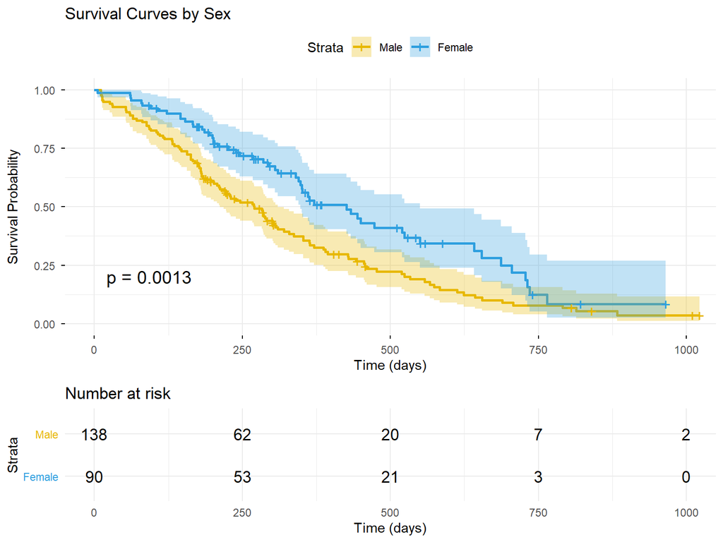

```r
# 使用lung数据集按性别分组
km_sex <- survfit(Surv(time, status - 1) ~ sex, data = lung_clean)

# 使用survminer绘制美观的KM曲线
ggsurvplot(km_sex,
           data = lung_clean,
           pval = TRUE,  # 显示p值
           conf.int = TRUE,  # 显示置信区间
           risk.table = TRUE,  # 显示风险表
           risk.table.height = 0.3,
           xlab = "Time (days)",
           ylab = "Survival Probability",
           title = "Survival Curves by Sex",
           legend.labs = c("Male", "Female"),
           palette = c("#E7B800", "#2E9FDF"),
           ggtheme = theme_minimal())
```

## 3.2 其他检验方法

### Wilcoxon检验和加权检验

```r
# Logrank (G^{0,0})
logrank <- survdiff(Surv(time, status - 1) ~ sex, data = lung_clean, rho = 0)
cat("Logrank Test (rho=0):\n")
```

```
## Logrank Test (rho=0):
```

```r
print(logrank)
```

```
## Call:
## survdiff(formula = Surv(time, status - 1) ~ sex, data = lung_clean,
##     rho = 0)
##
##         N Observed Expected (O-E)^2/E (O-E)^2/V
## sex=1 138      112     91.6      4.55      10.3
## sex=2  90       53     73.4      5.68      10.3
##
##  Chisq= 10.3  on 1 degrees of freedom, p= 0.001
```

```r
# Peto-Peto / Wilcoxon (G^{1,0})
wilcoxon <- survdiff(Surv(time, status - 1) ~ sex, data = lung_clean, rho = 1)
cat("\nWilcoxon Test (rho=1, emphasizes early differences):\n")
```

```
##
## Wilcoxon Test (rho=1, emphasizes early differences):
```

```r
print(wilcoxon)
```

```
## Call:
## survdiff(formula = Surv(time, status - 1) ~ sex, data = lung_clean,
##     rho = 1)
##
##         N Observed Expected (O-E)^2/E (O-E)^2/V
## sex=1 138     70.4     55.6      3.95      12.7
## sex=2  90     28.7     43.5      5.04      12.7
##
##  Chisq= 12.7  on 1 degrees of freedom, p= 4e-04
```

```r
# 比较结果
cat("\n比较:\n")
```

```
##
## 比较:
```

```r
cat("Logrank chi-square:", logrank$chisq, ", p-value:",
    1 - pchisq(logrank$chisq, 1), "\n")
```

```
## Logrank chi-square: 10.32674 , p-value: 0.001311165
```

```r
cat("Wilcoxon chi-square:", wilcoxon$chisq, ", p-value:",
    1 - pchisq(wilcoxon$chisq, 1), "\n")
```

```
## Wilcoxon chi-square: 12.71415 , p-value: 0.0003628989
```

## 3.3 分层Logrank检验

```r
# 示例：控制ECOG表现状态后比较性别差异
# 首先检查数据
table(lung_clean$sex, lung_clean$ph.ecog)
```

```
##
##      0  1  2  3
##   1 36 71 29  1
##   2 27 42 21  0
```

```r
# 分层logrank检验
stratified_logrank <- survdiff(Surv(time, status - 1) ~ sex + strata(ph.ecog),
                                data = lung_clean)
print(stratified_logrank)
```

```
## Call:
## survdiff(formula = Surv(time, status - 1) ~ sex + strata(ph.ecog),
##     data = lung_clean)
##
## n=227, 1 observation deleted due to missingness.
##
##         N Observed Expected (O-E)^2/E (O-E)^2/V
## sex=1 137      111     90.6      4.57      10.8
## sex=2  90       53     73.4      5.65      10.8
##
##  Chisq= 10.8  on 1 degrees of freedom, p= 0.001
```

```r
# 比较非分层和分层结果
cat("\n非分层 Logrank:\n")
```

```
##
## 非分层 Logrank:
```

```r
print(survdiff(Surv(time, status - 1) ~ sex, data = lung_clean))
```

```
## Call:
## survdiff(formula = Surv(time, status - 1) ~ sex, data = lung_clean)
##
##         N Observed Expected (O-E)^2/E (O-E)^2/V
## sex=1 138      112     91.6      4.55      10.3
## sex=2  90       53     73.4      5.68      10.3
##
##  Chisq= 10.3  on 1 degrees of freedom, p= 0.001
```

```r
cat("\n分层 Logrank (by ECOG performance status):\n")
```

```
##
## 分层 Logrank (by ECOG performance status):
```

```r
print(stratified_logrank)
```

```
## Call:
## survdiff(formula = Surv(time, status - 1) ~ sex + strata(ph.ecog),
##     data = lung_clean)
##
## n=227, 1 observation deleted due to missingness.
##
##         N Observed Expected (O-E)^2/E (O-E)^2/V
## sex=1 137      111     90.6      4.57      10.8
## sex=2  90       53     73.4      5.65      10.8
##
##  Chisq= 10.8  on 1 degrees of freedom, p= 0.001
```

# Chapter 4: Cox比例风险模型

## 4.1 Cox模型基础

### 单变量Cox模型

```r
# 单变量分析：性别
cox_sex <- coxph(Surv(time, status - 1) ~ sex, data = lung_clean)
summary(cox_sex)
```

```
## Call:
## coxph(formula = Surv(time, status - 1) ~ sex, data = lung_clean)
##
##   n= 228, number of events= 165
##
##        coef exp(coef) se(coef)      z Pr(>|z|)
## sex -0.5310    0.5880   0.1672 -3.176  0.00149 **
## ---
## Signif. codes:  0 '***' 0.001 '**' 0.01 '*' 0.05 '.' 0.1 ' ' 1
##
##     exp(coef) exp(-coef) lower .95 upper .95
## sex     0.588      1.701    0.4237     0.816
##
## Concordance= 0.579  (se = 0.021 )
## Likelihood ratio test= 10.63  on 1 df,   p=0.001
## Wald test            = 10.09  on 1 df,   p=0.001
## Score (logrank) test = 10.33  on 1 df,   p=0.001
```

```r
# 提取关键信息
cat("\n关键结果解读:\n")
```

```
##
## 关键结果解读:
```

```r
cat("Coefficient (beta):", coef(cox_sex), "\n")
```

```
## Coefficient (beta): -0.5310235
```

```r
cat("Hazard Ratio:", exp(coef(cox_sex)), "\n")
```

```
## Hazard Ratio: 0.5880028
```

```r
cat("95% CI for HR:", exp(confint(cox_sex)), "\n")
```

```
## 95% CI for HR: 0.4237178 0.8159848
```

```r
cat("Wald test p-value:", summary(cox_sex)$coefficients[, "Pr(>|z|)"], "\n")
```

```
## Wald test p-value: 0.001491229
```

```r
# 解释
cat("\n解释:\n")
```

```
##
## 解释:
```

```r
cat("女性相比男性的风险比 =", round(exp(coef(cox_sex)), 3), "\n")
```

```
## 女性相比男性的风险比 = 0.588
```

```r
cat("女性死亡风险降低", round((1 - exp(coef(cox_sex))) * 100, 1), "%\n")
```

```
## 女性死亡风险降低 41.2 %
```

### Cox模型的Partial Likelihood（部分似然）

**重要概念**：Cox模型使用**partial likelihood**而不是完整的likelihood。

- **原因**：Cox模型是半参数模型，不对基线风险$h_0(t)$做参数假设
- **方法**：通过条件在每个事件时间的风险集上，避免估计$h_0(t)$
- **公式**：
  $$L(\beta) =
  \prod_{i=1}^D \frac{\exp(\beta^T Z_{(i)})}{\sum_{j \in R(t_{(i)})}
  \exp(\beta^T Z_j)}$$

其中$R(t_i)$是时间$t_i$的风险集

- **优点**：
  1. 不需要指定$h_0(t)$的参数形式
  2. 仍然可以进行有效推断
  3. 计算相对简单

### 多变量Cox模型

```r
# 多变量模型
cox_multi <- coxph(Surv(time, status - 1) ~ sex + age + ph.ecog,
                   data = lung_clean)
summary(cox_multi)
```

```
## Call:
## coxph(formula = Surv(time, status - 1) ~ sex + age + ph.ecog,
##     data = lung_clean)
##
##   n= 227, number of events= 164
##    (1 observation deleted due to missingness)
##
##              coef exp(coef)  se(coef)      z Pr(>|z|)
## sex     -0.552612  0.575445  0.167739 -3.294 0.000986 ***
## age      0.011067  1.011128  0.009267  1.194 0.232416
## ph.ecog  0.463728  1.589991  0.113577  4.083 4.45e-05 ***
## ---
## Signif. codes:  0 '***' 0.001 '**' 0.01 '*' 0.05 '.' 0.1 ' ' 1
##
##         exp(coef) exp(-coef) lower .95 upper .95
## sex        0.5754     1.7378    0.4142    0.7994
## age        1.0111     0.9890    0.9929    1.0297
## ph.ecog    1.5900     0.6289    1.2727    1.9864
##
## Concordance= 0.637  (se = 0.025 )
## Likelihood ratio test= 30.5  on 3 df,   p=1e-06
## Wald test            = 29.93  on 3 df,   p=1e-06
## Score (logrank) test = 30.5  on 3 df,   p=1e-06
```

```r
cat("\n注意：Cox模型使用partial likelihood进行估计\n")
```

```
##
## 注意：Cox模型使用partial likelihood进行估计
```

```r
cat("这意味着我们最大化partial likelihood而非完整likelihood\n")
```

```
## 这意味着我们最大化partial likelihood而非完整likelihood
```

```r
# 比较调整前后的HR
cat("\n未调整 vs 调整后的HR (性别):\n")
```

```
##
## 未调整 vs 调整后的HR (性别):
```

```r
cat("未调整 HR:", exp(coef(cox_sex)), "\n")
```

```
## 未调整 HR: 0.5880028
```

```r
cat("调整后 HR:", exp(coef(cox_multi)["sex"]), "\n")
```

```
## 调整后 HR: 0.5754446
```

```r
cat("变化百分比:",
    round((exp(coef(cox_multi)["sex"]) - exp(coef(cox_sex))) / exp(coef(cox_sex)) * 100, 1),
    "%\n")
```

```
## 变化百分比: -2.1 %
```

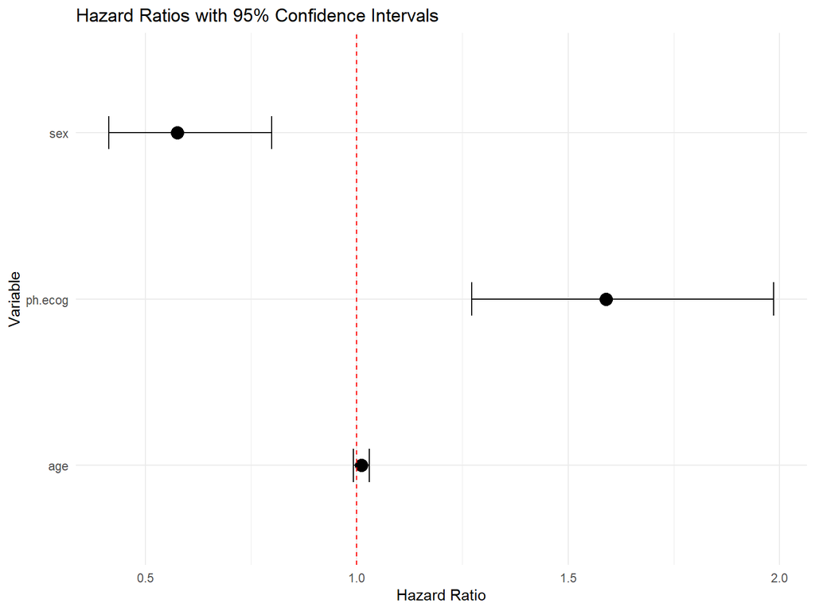

```r
# 可视化HR和置信区间
hr_data <- data.frame(
  variable = names(coef(cox_multi)),
  hr = exp(coef(cox_multi)),
  lower = exp(confint(cox_multi)[, 1]),
  upper = exp(confint(cox_multi)[, 2])
)

ggplot(hr_data, aes(x = variable, y = hr)) +
  geom_point(size = 4) +
  geom_errorbar(aes(ymin = lower, ymax = upper), width = 0.2) +
  geom_hline(yintercept = 1, linetype = "dashed", color = "red") +
  coord_flip() +
  labs(title = "Hazard Ratios with 95% Confidence Intervals",
       x = "Variable", y = "Hazard Ratio") +
  theme_minimal()
```